# MA50258: Applied Statistics

## Question 4

Fit the LOESS empirical estimate (joint with interaction) of the regression function $s$ in the model:

$$E[\verb|q3||\verb|q1|,\verb|championship_points|]=s(\verb|q1|,log_{10}(\verb|championship_points|))$$

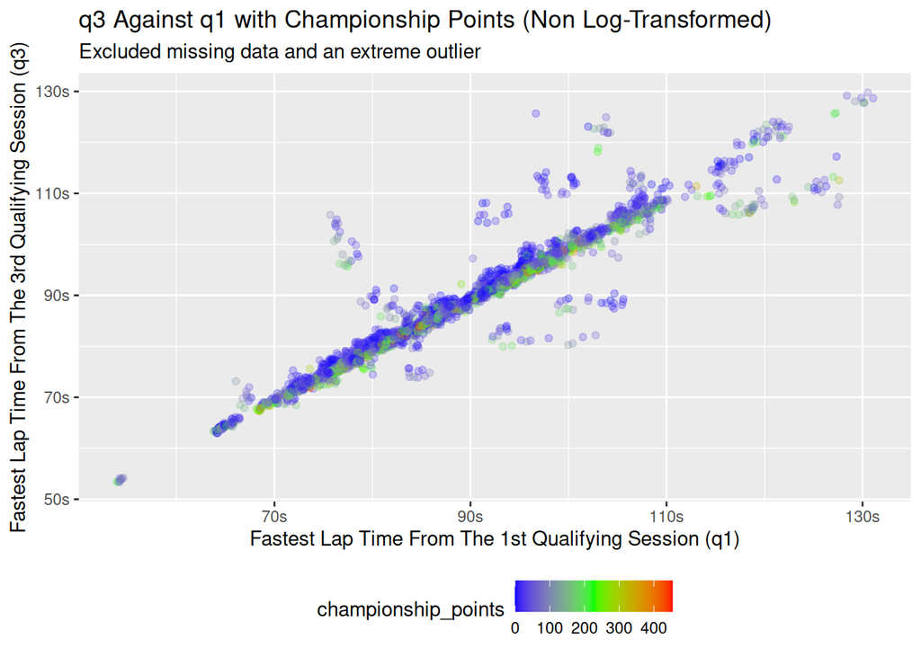

```r
# EDA Code
# Check for relationship between q1 and championship_points
formula_eda_q4 <- formula_tom %>% drop_na(championship_points, q1_in_seconds, q3_in_seconds) %>%  filter(q1_in_seconds < 180)
log10_championship_points <- log10(formula_eda_q4$championship_points + 1)
ggplot(
  formula_eda_q4,
  aes(x = q1_in_seconds, y = q3_in_seconds, col = championship_points)) +
  geom_point(alpha = 0.25) +
  # geom_smooth(aes(col = "loess smoothing"), method = "loess", se = F, linewidth = 0.5) +
  labs(
    title = "q3 Against q1 with Championship Points (Non Log-Transformed)",
    x = "Fastest Lap Time From The 1st Qualifying Session (q1)",
    y = "Fastest Lap Time From The 3rd Qualifying Session (q3)",
    subtitle = "Excluded missing data and an extreme outlier"
  ) +
  theme(legend.position = "bottom") +
  scale_colour_gradient2(
    low = "blue",
    mid = "green",
    high = "red",
    midpoint = median(max(formula_eda_q4$championship_points)/2, na.rm = TRUE)
  ) +
  scale_x_continuous(labels = function(x) paste0(x, "s")) +
  scale_y_continuous(labels = function(y) paste0(y, "s"))
```

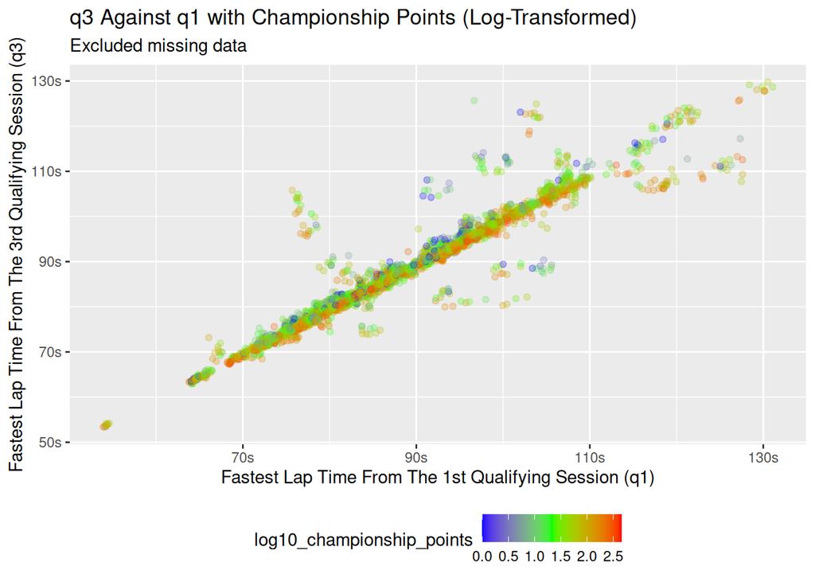

```r
ggplot(
  formula_eda_q4,
  aes(x = q1_in_seconds, y = q3_in_seconds, col = log10_championship_points)) +
  geom_point(alpha = 0.25) +
  labs(
    title = "q3 Against q1 with Championship Points (Log-Transformed)",
    x = "Fastest Lap Time From The 1st Qualifying Session (q1)",
    y = "Fastest Lap Time From The 3rd Qualifying Session (q3)",
    subtitle = "Excluded missing data"
  ) +
  theme(legend.position = "bottom") +
  scale_colour_gradient2(
    low = "blue",
    mid = "green",
    high = "red",
    midpoint = median(max(log10_championship_points)/2, na.rm = TRUE)
  ) +
  scale_x_continuous(labels = function(x) paste0(x, "s")) +
  scale_y_continuous(labels = function(y) paste0(y, "s"))
```

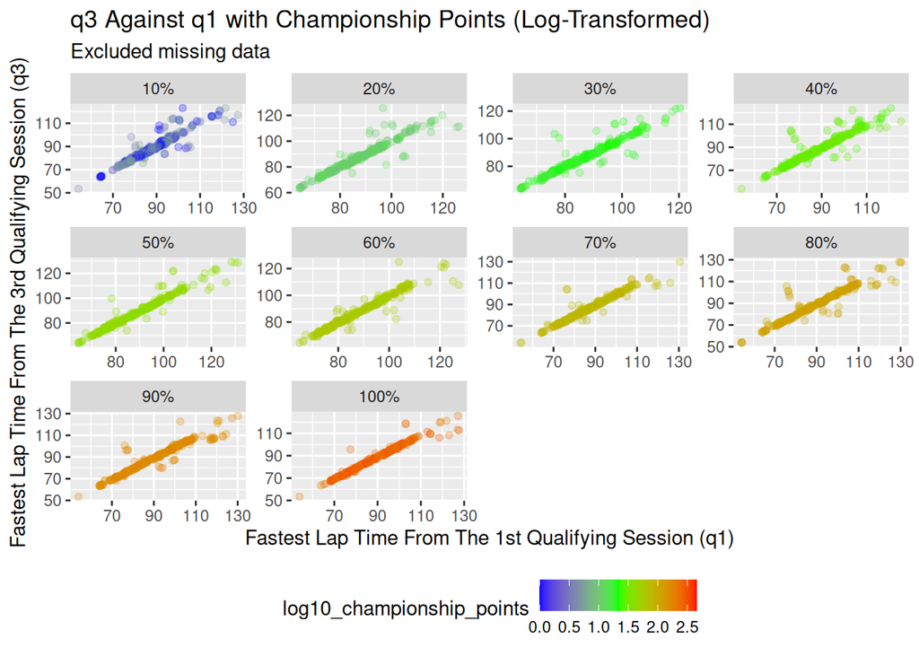

```r
# Include the deciles (Breaking up log10_championship_points into deciles)
formula_eda_q4_break_points <- formula_eda_q4 %>%
  mutate(decile = cut(log10_championship_points,
                      breaks = quantile(log10_championship_points,
                                        probs = seq(0, 1, by = 0.1)),
                      include.lowest = TRUE,
                      labels = paste0(seq(10, 100, by = 10), "%")))  # Label the deciles

ggplot(
  formula_eda_q4_break_points,
  aes(x = q1_in_seconds, y = q3_in_seconds, col = log10_championship_points)) +
  geom_point(alpha = 0.25) +
  labs(
    title = "q3 Against q1 with Championship Points (Log-Transformed)",
    x = "Fastest Lap Time From The 1st Qualifying Session (q1)",
    y = "Fastest Lap Time From The 3rd Qualifying Session (q3)",
    subtitle = "Excluded missing data"
  ) +
  theme(legend.position = "bottom") +
  scale_colour_gradient2(
    low = "blue",
    mid = "green",
    high = "red",
    midpoint = median(max(log10_championship_points)/2, na.rm = TRUE)
  ) +
  facet_wrap(~decile, scales = "free", ncol = 4)
```

```r
# EDA Code
# Fit the linear model with interaction
formula_tom_no_na_q4 <- formula_tom %>% drop_na(q1_in_seconds, q3_in_seconds, championship_points) # %>% filter(q1_in_seconds < 180)

# Add +1 to avoid log(0) error
formula_tom_no_na_q4_log10_championship_points <- log10(formula_tom_no_na_q4$championship_points + 1)
lm_model_q4 <- lm(q3_in_seconds ~ q1_in_seconds + formula_tom_no_na_q4_log10_championship_points + q1_in_seconds*formula_tom_no_na_q4_log10_championship_points, data = formula_tom_no_na_q4)

# Create the table
kable(
  summary(lm_model_q4)$coefficients %>%
    as.data.frame() %>%
    select(Estimate, `Std. Error`),
  caption = "Summary of the Linear Model Fit",
  digits = 2,
  align = "c"
) %>%
  kable_styling("striped", full_width = F, position = "center")
```

Summary of the Linear Model Fit

|  | Estimate | Std. Error |
| --- | --- | --- |
| (Intercept) | 0.82 | 1.44 |
| q1_in_seconds | 1.00 | 0.02 |
| formula_tom_no_na_q4_log10_championship_points | 1.51 | 0.82 |
| q1_in_seconds:formula_tom_no_na_q4_log10_championship_points | -0.03 | 0.01 |

```r
# Fit the LOESS model with interaction
loess_model_q4 <- loess(q3_in_seconds ~ q1_in_seconds + formula_tom_no_na_q4_log10_championship_points + q1_in_seconds*formula_tom_no_na_q4_log10_championship_points, data = formula_tom_no_na_q4)

# Create the table
# TODO: Tidy up the loess output
summary(loess_model_q4)
```

```
## Call:
## loess(formula = q3_in_seconds ~ q1_in_seconds + formula_tom_no_na_q4_log10_championship_points +
##     q1_in_seconds * formula_tom_no_na_q4_log10_championship_points,
##     data = formula_tom_no_na_q4)
##
## Number of Observations: 3285
## Equivalent Number of Parameters: 11.1
## Residual Standard Error: 3.48
## Trace of smoother matrix: 12.94  (exact)
##
## Control settings:
##   span     :  0.75
##   degree   :  2
##   family   :  gaussian
##   surface  :  interpolate      cell = 0.2
##   normalize:  TRUE
##  parametric:  FALSE FALSE
## drop.square:  FALSE FALSE
```

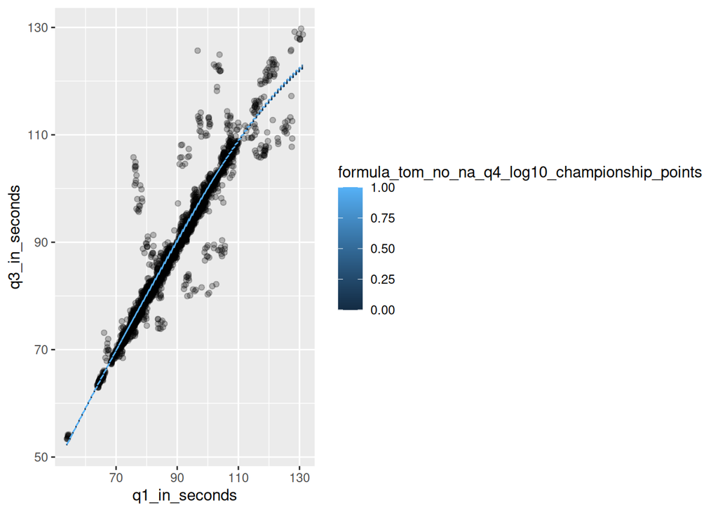

```r
library(modelr) # For using add_prediction and data_grid functions
mid_decile_points <- quantile(formula_tom_no_na_q4_log10_championship_points, probs = seq(0, 2.75, by = 0.25)/20)
mid_decile_points <- signif(mid_decile_points, digits = 2)

# Add the decile information to the formula_tom_no_na_q4 dataframe
pred_grid <-
  formula_tom_no_na_q4 %>%
  data_grid(
    formula_tom_no_na_q4_log10_championship_points = mid_decile_points,
    q1_in_seconds = seq(min(formula_tom_no_na_q4$q1_in_seconds), max(formula_tom_no_na_q4$q1_in_seconds))) %>%
  add_predictions(loess_model_q4, var = "q3_in_seconds", type = "response")

formula_tom_no_na_q4 %>%
ggplot(
  aes(x = q1_in_seconds, y = q3_in_seconds)) +
  geom_point(alpha = 0.25) +
  geom_line(aes(x = q1_in_seconds, y = q3_in_seconds, col = formula_tom_no_na_q4_log10_championship_points), data = pred_grid)
```

also, fit the following linear regression model:

$$\begin{multline}
e[\verb|q3||\verb|q1|,log_{10}(\verb|championship_points|)]=\\
\delta_0 + \delta_1\,\verb|q1| +\delta_2
\,log_{10}(\verb|championship_points|) +
\delta_3\,\verb|q1|\,\times\,log_{10}(\verb|championship_points|)
\end{multline}$$

For both the linear model and the LOESS model:

- Plot the effect of `championship_points` on `q3`.
- Plot the effect of `q1` on `q3` for mid-deciles (eg percentiles of order 5%, 15%, 25%, …, 95%) of `championship_points.`

Interpret both effect plots and comment on the fit the transformed linear model to the data. Also, give an interpretation of the estimated parameters in this model (apart from the intercept).